# STAT 240 Discussion 2

individual

## Members Present

**Steven Hizmi**

## Members Absent

- none

## Grading

The assignment has 6 questions. Your groups score will be based on Questions 1, 2, 4, and 6, so do these questions first. If you have more time, work to complete the remaining questions.

## Exoplanet Data

We will be working with data on exoplanets; exoplanets are planets orbiting stars outside our Solar System. The data were pulled from the [NASA Exoplanet Archive](https://exoplanetarchive.ipac.caltech.edu/index.html) on September 3, 2020 (with 4,276 exoplanets confirmed as of this date, but this data set includes planet *candidates* as well).

```r
## Read in the csv file
## There is one row per exoplanet
## Select some variables that we will work with and rename them
## Remove very massive planet (only to improve plot visuals)
## Drop missing values; the remaining exoplanets will have estimates of both mass and radius
planets <- read_csv("../../data/exoplanets-3sept2020.csv") %>%
  select(pl_name, discoverymethod, disc_year, sy_pnum, pl_rade, pl_bmasse) %>%
  rename(name=pl_name, method=discoverymethod,year=disc_year, number=sy_pnum, radius=pl_rade, mass=pl_bmasse) %>%
  filter(mass <10000) %>%
  drop_na()
```

The variables we will be working with are defined below. If you want more details, please see the exoplanet archive [data column definitions](https://exoplanetarchive.ipac.caltech.edu/docs/API_PS_columns.html) (using the column names in the raw data).

`name` = Planet Name `method` = Method by which the planet was first identified `year` = Discovery Year (the year it was discovered) `number` = Number of Planets `radius` = Planet Radius (units: Earth Radius) `mass` = Approximate or Minimum Planet Mass (units: Earth Mass)

## Questions

The questions use a subset of the data with only some columns and filtering out exoplanets that have missing values in our selected columns.

### Question 1

> Make a scatter plot with `year` (discovery year) on the x-axis and `mass` (the estimate of the planet mass) on the vertical axis. The `scale_y_log10()` is added to change the y-axis values to a `log10()` scale.

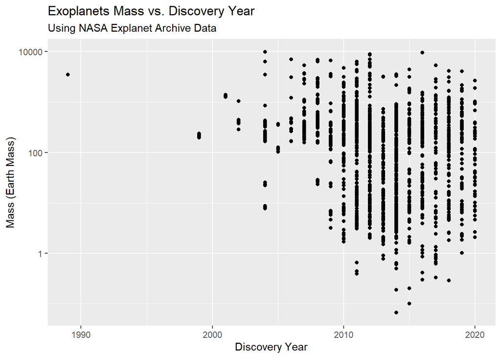

```r
## COMPLETE CODE TO MAKE THIS PLOT
ggplot(planets, aes(x = year, y = mass)) + geom_point() +
  scale_y_log10() +
  xlab("Discovery Year") +
  ylab("Mass (Earth Mass)") +
  ggtitle("Exoplanets Mass vs. Discovery Year",
          subtitle="Using NASA Explanet Archive Data")
```

### Question 2

> Make a scatter plot like the previous problem, but use the `color` aesthetic for `method` (discovery method).

> (Your call to `aes()` will look like `aes(year, mass,color=method)`)

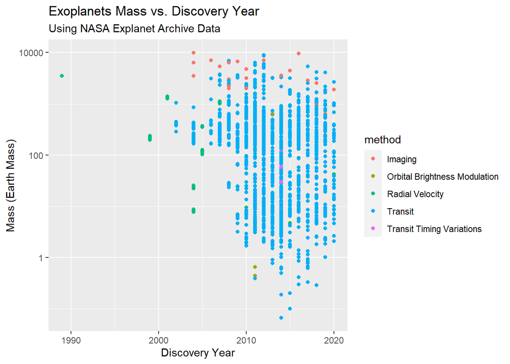

```r
## COMPLETE CODE TO MAKE THIS PLOT
ggplot(planets, aes(x = year, y = mass, color=method)) + geom_point() +
  scale_y_log10() +
  xlab("Discovery Year") +
  ylab("Mass (Earth Mass)") +
  ggtitle("Exoplanets Mass vs. Discovery Year",
          subtitle="Using NASA Explanet Archive Data")
```

### Question 3

> Which method has discovered the lowest mass planets?  
> Do you notice any pattern between the low mass planets and discovery year?  
> Which method had the earliest planet discoveries?  
> (This is using our filtered data which uses exoplanets that have both an estimated mass and an estimated radius; these patterns may not hold in general.)

### Question 4

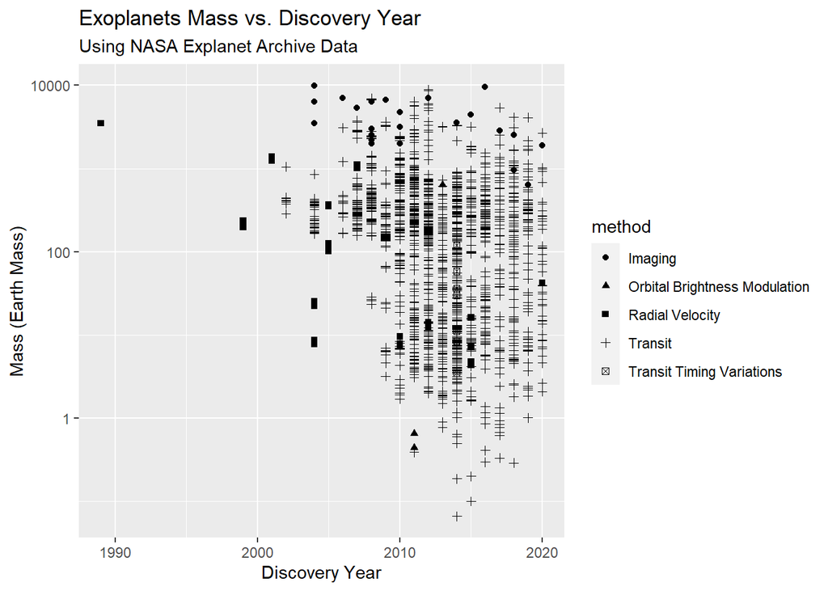

```r
## COMPLETE CODE TO MAKE THIS PLOT
ggplot(planets, aes(x = year, y = mass, shape=method)) + geom_point() +
  scale_y_log10() +
  xlab("Discovery Year") +
  ylab("Mass (Earth Mass)") +
  ggtitle("Exoplanets Mass vs. Discovery Year",
          subtitle="Using NASA Explanet Archive Data")
```

### Question 5

> Does shape or color work better for distinguishing among the discovery methods? Briefly explain.

#### Response

I think color works the best, shape is not clear enough for a graph like this.

### Question 6

> Another way to display differences by discovery method is to separate the plot into multiple panels (or facets) and plot different subsets of the data in each. We are going to look at planet mass versus planet radius here (both on log10 scales). Add a comment to say what the code on the next line does where indicated.

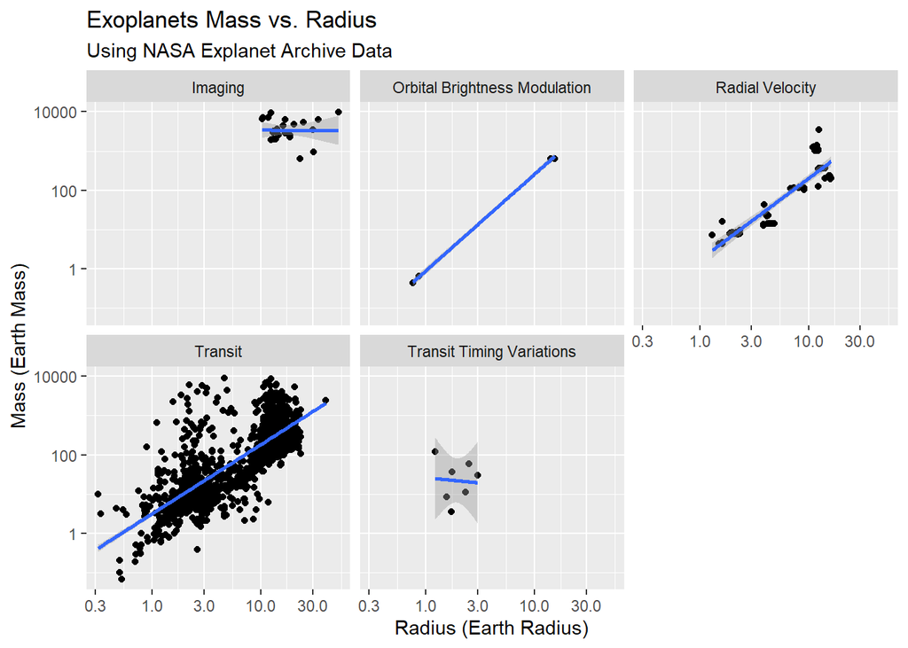

```r
ggplot(planets, aes(x=radius,y=mass)) +
  geom_point() +
  scale_y_log10() +
  scale_x_log10() +
  ## adds a line of best fit for each graph in the output
  geom_smooth(method="lm") +
  ## Lets you read all 5 graphs at once rather than the Exoplanets Mass vs. Radius graph
  facet_wrap(~method) +
  xlab("Radius (Earth Radius)") +
  ylab("Mass (Earth Mass)") +
  ggtitle("Exoplanets Mass vs. Radius",
          subtitle="Using NASA Explanet Archive Data")
```